# Risk Factor Analysis

## Outcome Variable

**Outcome Variable:** swasted

## Predictor Variables

**Intervention Variable:** hfoodsec

**Adjustment Set:**

- arm
- sex
- W_mage
- meducyrs
- feducyrs
- hhwealth_quart
- vagbrth
- W_nrooms
- W_nchldlt5
- brthmon
- W_parity
- impfloor
- impsan
- safeh20
- delta_W_mage
- delta_meducyrs
- delta_feducyrs
- delta_hhwealth_quart
- delta_vagbrth
- delta_W_nrooms
- delta_W_nchldlt5
- delta_brthmon
- delta_W_parity
- delta_impfloor
- delta_impsan
- delta_safeh20

## Stratifying Variables

The analysis was stratified on these variable(s):

- agecat
- studyid
- country

## Data Summary

| agecat | studyid | country | hfoodsec | swasted | n_cell | n |
| --- | --- | --- | --- | --- | --- | --- |
| Birth | GMS-Nepal | NEPAL | Food Secure | 0 | 423 | 620 |
| Birth | GMS-Nepal | NEPAL | Food Secure | 1 | 19 | 620 |
| Birth | GMS-Nepal | NEPAL | Mildly Food Insecure | 0 | 98 | 620 |
| Birth | GMS-Nepal | NEPAL | Mildly Food Insecure | 1 | 2 | 620 |
| Birth | GMS-Nepal | NEPAL | Food Insecure | 0 | 74 | 620 |
| Birth | GMS-Nepal | NEPAL | Food Insecure | 1 | 4 | 620 |
| Birth | JiVitA-3 | BANGLADESH | Food Secure | 0 | 5713 | 11763 |
| Birth | JiVitA-3 | BANGLADESH | Food Secure | 1 | 84 | 11763 |
| Birth | JiVitA-3 | BANGLADESH | Mildly Food Insecure | 0 | 3876 | 11763 |
| Birth | JiVitA-3 | BANGLADESH | Mildly Food Insecure | 1 | 71 | 11763 |
| Birth | JiVitA-3 | BANGLADESH | Food Insecure | 0 | 1984 | 11763 |
| Birth | JiVitA-3 | BANGLADESH | Food Insecure | 1 | 35 | 11763 |
| Birth | JiVitA-4 | BANGLADESH | Food Secure | 0 | 1190 | 2383 |
| Birth | JiVitA-4 | BANGLADESH | Food Secure | 1 | 15 | 2383 |
| Birth | JiVitA-4 | BANGLADESH | Mildly Food Insecure | 0 | 858 | 2383 |
| Birth | JiVitA-4 | BANGLADESH | Mildly Food Insecure | 1 | 12 | 2383 |
| Birth | JiVitA-4 | BANGLADESH | Food Insecure | 0 | 304 | 2383 |
| Birth | JiVitA-4 | BANGLADESH | Food Insecure | 1 | 4 | 2383 |
| Birth | MAL-ED | BANGLADESH | Food Secure | 0 | 133 | 162 |
| Birth | MAL-ED | BANGLADESH | Food Secure | 1 | 5 | 162 |
| Birth | MAL-ED | BANGLADESH | Mildly Food Insecure | 0 | 3 | 162 |
| Birth | MAL-ED | BANGLADESH | Mildly Food Insecure | 1 | 0 | 162 |
| Birth | MAL-ED | BANGLADESH | Food Insecure | 0 | 19 | 162 |
| Birth | MAL-ED | BANGLADESH | Food Insecure | 1 | 2 | 162 |
| Birth | MAL-ED | BRAZIL | Food Secure | 0 | 0 | 26 |
| Birth | MAL-ED | BRAZIL | Food Secure | 1 | 0 | 26 |
| Birth | MAL-ED | BRAZIL | Mildly Food Insecure | 0 | 4 | 26 |
| Birth | MAL-ED | BRAZIL | Mildly Food Insecure | 1 | 0 | 26 |
| Birth | MAL-ED | BRAZIL | Food Insecure | 0 | 22 | 26 |
| Birth | MAL-ED | BRAZIL | Food Insecure | 1 | 0 | 26 |

[output cut: 168 more lines]

The following strata were considered:

- agecat: 24 months, studyid: GMS-Nepal, country: NEPAL
- agecat: 24 months, studyid: JiVitA-3, country: BANGLADESH
- agecat: 24 months, studyid: JiVitA-4, country: BANGLADESH
- agecat: 24 months, studyid: MAL-ED, country: BANGLADESH
- agecat: 24 months, studyid: MAL-ED, country: BRAZIL
- agecat: 24 months, studyid: MAL-ED, country: INDIA
- agecat: 24 months, studyid: MAL-ED, country: NEPAL
- agecat: 24 months, studyid: MAL-ED, country: PERU
- agecat: 24 months, studyid: MAL-ED, country: SOUTH AFRICA
- agecat: 24 months, studyid: NIH-Birth, country: BANGLADESH
- agecat: 24 months, studyid: NIH-Crypto, country: BANGLADESH
- agecat: 6 months, studyid: GMS-Nepal, country: NEPAL
- agecat: 6 months, studyid: JiVitA-3, country: BANGLADESH
- agecat: 6 months, studyid: JiVitA-4, country: BANGLADESH
- agecat: 6 months, studyid: MAL-ED, country: BANGLADESH
- agecat: 6 months, studyid: MAL-ED, country: BRAZIL
- agecat: 6 months, studyid: MAL-ED, country: INDIA
- agecat: 6 months, studyid: MAL-ED, country: NEPAL
- agecat: 6 months, studyid: MAL-ED, country: PERU
- agecat: 6 months, studyid: MAL-ED, country: SOUTH AFRICA
- agecat: 6 months, studyid: NIH-Birth, country: BANGLADESH
- agecat: 6 months, studyid: NIH-Crypto, country: BANGLADESH
- agecat: Birth, studyid: GMS-Nepal, country: NEPAL
- agecat: Birth, studyid: JiVitA-3, country: BANGLADESH
- agecat: Birth, studyid: JiVitA-4, country: BANGLADESH
- agecat: Birth, studyid: MAL-ED, country: BANGLADESH
- agecat: Birth, studyid: MAL-ED, country: BRAZIL
- agecat: Birth, studyid: MAL-ED, country: INDIA
- agecat: Birth, studyid: MAL-ED, country: NEPAL
- agecat: Birth, studyid: MAL-ED, country: PERU
- agecat: Birth, studyid: MAL-ED, country: SOUTH AFRICA
- agecat: Birth, studyid: NIH-Birth, country: BANGLADESH
- agecat: Birth, studyid: NIH-Crypto, country: BANGLADESH

### Dropped Strata

Some strata were dropped due to rare outcomes:

- agecat: Birth, studyid: GMS-Nepal, country: NEPAL
- agecat: Birth, studyid: JiVitA-4, country: BANGLADESH
- agecat: Birth, studyid: MAL-ED, country: BANGLADESH
- agecat: Birth, studyid: MAL-ED, country: BRAZIL
- agecat: Birth, studyid: MAL-ED, country: INDIA
- agecat: Birth, studyid: MAL-ED, country: NEPAL
- agecat: Birth, studyid: MAL-ED, country: PERU
- agecat: Birth, studyid: MAL-ED, country: SOUTH AFRICA
- agecat: Birth, studyid: NIH-Birth, country: BANGLADESH
- agecat: Birth, studyid: NIH-Crypto, country: BANGLADESH
- agecat: 6 months, studyid: GMS-Nepal, country: NEPAL
- agecat: 6 months, studyid: JiVitA-4, country: BANGLADESH
- agecat: 6 months, studyid: MAL-ED, country: BANGLADESH
- agecat: 6 months, studyid: MAL-ED, country: BRAZIL
- agecat: 6 months, studyid: MAL-ED, country: INDIA
- agecat: 6 months, studyid: MAL-ED, country: NEPAL
- agecat: 6 months, studyid: MAL-ED, country: PERU
- agecat: 6 months, studyid: MAL-ED, country: SOUTH AFRICA
- agecat: 6 months, studyid: NIH-Birth, country: BANGLADESH
- agecat: 6 months, studyid: NIH-Crypto, country: BANGLADESH
- agecat: 24 months, studyid: GMS-Nepal, country: NEPAL
- agecat: 24 months, studyid: MAL-ED, country: BANGLADESH
- agecat: 24 months, studyid: MAL-ED, country: BRAZIL
- agecat: 24 months, studyid: MAL-ED, country: INDIA
- agecat: 24 months, studyid: MAL-ED, country: NEPAL
- agecat: 24 months, studyid: MAL-ED, country: PERU
- agecat: 24 months, studyid: MAL-ED, country: SOUTH AFRICA
- agecat: 24 months, studyid: NIH-Birth, country: BANGLADESH
- agecat: 24 months, studyid: NIH-Crypto, country: BANGLADESH

## Methods Detail

We’re interested in the causal parameters $E[Y_a]$ for all values of $a \in \mathcal{A}$. These parameters represent the mean outcome if, possibly contrary to fact, we intervened to set all units to have $A=a$. Under the randomization and positivity assumptions, these are identified by the statistical parameters $\psi_a=E_W[E_{Y|A,W}(Y|A=a,W)]$. In addition, we’re interested in the mean of $Y$, $E[Y]$ under no intervention (the observed mean). We will estimate these parameters by using SuperLearner to fit the relevant likelihood factors – $E_{Y|A,W}(Y|A=a,W)$ and $p(A=a|W)$, and then updating our likelihood fit using a joint TMLE.

For unadjusted analyses ($W=\{\}$), initial likelihoods were estimated using Lrnr_glm to estimate the simple $E(Y|A)$ and Lrnr_mean to estimate $p(A)$. For adjusted analyses, a small library containing Lrnr_glmnet, Lrnr_xgboost, and Lrnr_mean was used.

Having estimated these parameters, we will then use the delta method to estimate relative risks and attributable risks relative to a prespecified baseline level of $A$.

# Results Detail

## Results Plots

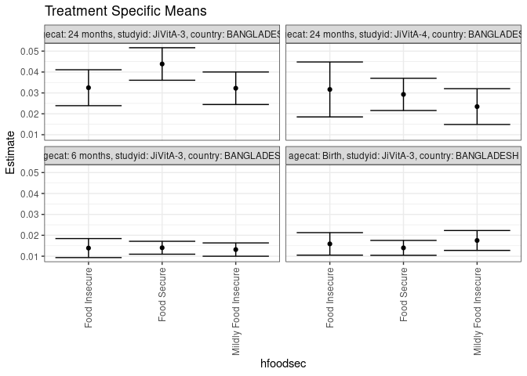

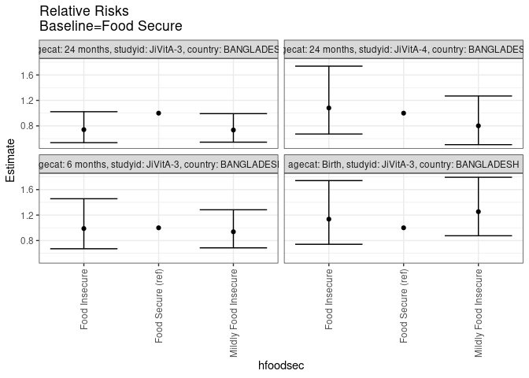

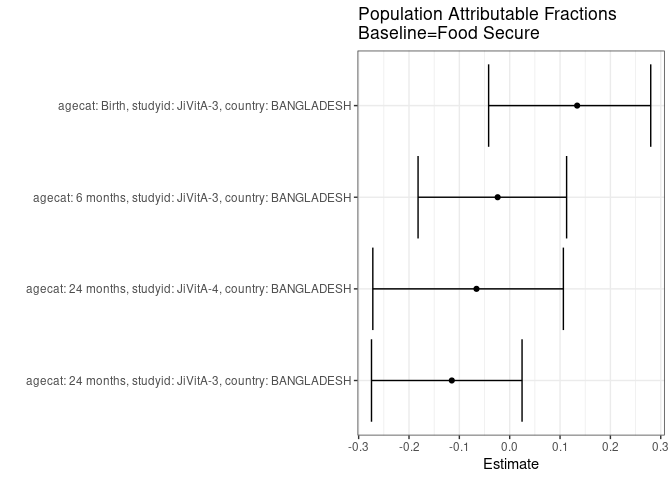

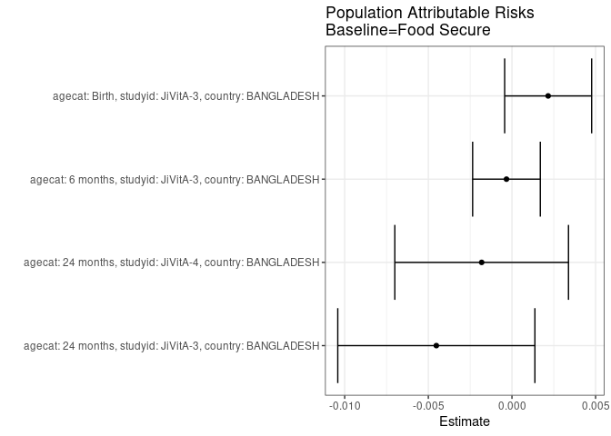

## Results Table

### Parameter: TSM

| agecat | studyid | country | intervention_level | baseline_level | estimate | ci_lower | ci_upper |
| --- | --- | --- | --- | --- | --- | --- | --- |
| Birth | JiVitA-3 | BANGLADESH | Food Secure | NA | 0.0139883 | 0.0104245 | 0.0175522 |
| Birth | JiVitA-3 | BANGLADESH | Mildly Food Insecure | NA | 0.0175255 | 0.0127707 | 0.0222803 |
| Birth | JiVitA-3 | BANGLADESH | Food Insecure | NA | 0.0158895 | 0.0104979 | 0.0212811 |
| 6 months | JiVitA-3 | BANGLADESH | Food Secure | NA | 0.0140479 | 0.0109685 | 0.0171273 |
| 6 months | JiVitA-3 | BANGLADESH | Mildly Food Insecure | NA | 0.0131734 | 0.0099811 | 0.0163657 |
| 6 months | JiVitA-3 | BANGLADESH | Food Insecure | NA | 0.0138884 | 0.0093407 | 0.0184361 |
| 24 months | JiVitA-3 | BANGLADESH | Food Secure | NA | 0.0438374 | 0.0360653 | 0.0516095 |
| 24 months | JiVitA-3 | BANGLADESH | Mildly Food Insecure | NA | 0.0322311 | 0.0244592 | 0.0400030 |
| 24 months | JiVitA-3 | BANGLADESH | Food Insecure | NA | 0.0324864 | 0.0238958 | 0.0410769 |
| 24 months | JiVitA-4 | BANGLADESH | Food Secure | NA | 0.0292821 | 0.0215801 | 0.0369840 |
| 24 months | JiVitA-4 | BANGLADESH | Mildly Food Insecure | NA | 0.0234608 | 0.0149046 | 0.0320170 |
| 24 months | JiVitA-4 | BANGLADESH | Food Insecure | NA | 0.0316599 | 0.0185102 | 0.0448096 |

### Parameter: E(Y)

| agecat | studyid | country | intervention_level | baseline_level | estimate | ci_lower | ci_upper |
| --- | --- | --- | --- | --- | --- | --- | --- |
| Birth | JiVitA-3 | BANGLADESH | NA | NA | 0.0161523 | 0.0134079 | 0.0188967 |
| 6 months | JiVitA-3 | BANGLADESH | NA | NA | 0.0137199 | 0.0116432 | 0.0157966 |
| 24 months | JiVitA-3 | BANGLADESH | NA | NA | 0.0393162 | 0.0348276 | 0.0438049 |
| 24 months | JiVitA-4 | BANGLADESH | NA | NA | 0.0274702 | 0.0222302 | 0.0327101 |

### Parameter: RR

| agecat | studyid | country | intervention_level | baseline_level | estimate | ci_lower | ci_upper |
| --- | --- | --- | --- | --- | --- | --- | --- |
| Birth | JiVitA-3 | BANGLADESH | Food Secure | Food Secure | 1.0000000 | 1.0000000 | 1.0000000 |
| Birth | JiVitA-3 | BANGLADESH | Mildly Food Insecure | Food Secure | 1.2528642 | 0.8752548 | 1.7933849 |
| Birth | JiVitA-3 | BANGLADESH | Food Insecure | Food Secure | 1.1359089 | 0.7411901 | 1.7408340 |
| 6 months | JiVitA-3 | BANGLADESH | Food Secure | Food Secure | 1.0000000 | 1.0000000 | 1.0000000 |
| 6 months | JiVitA-3 | BANGLADESH | Mildly Food Insecure | Food Secure | 0.9377485 | 0.6853143 | 1.2831662 |
| 6 months | JiVitA-3 | BANGLADESH | Food Insecure | Food Secure | 0.9886502 | 0.6712402 | 1.4561542 |
| 24 months | JiVitA-3 | BANGLADESH | Food Secure | Food Secure | 1.0000000 | 1.0000000 | 1.0000000 |
| 24 months | JiVitA-3 | BANGLADESH | Mildly Food Insecure | Food Secure | 0.7352428 | 0.5445912 | 0.9926379 |
| 24 months | JiVitA-3 | BANGLADESH | Food Insecure | Food Secure | 0.7410652 | 0.5367503 | 1.0231530 |
| 24 months | JiVitA-4 | BANGLADESH | Food Secure | Food Secure | 1.0000000 | 1.0000000 | 1.0000000 |
| 24 months | JiVitA-4 | BANGLADESH | Mildly Food Insecure | Food Secure | 0.8011990 | 0.5056553 | 1.2694810 |
| 24 months | JiVitA-4 | BANGLADESH | Food Insecure | Food Secure | 1.0812038 | 0.6726374 | 1.7379375 |

### Parameter: PAR

| agecat | studyid | country | intervention_level | baseline_level | estimate | ci_lower | ci_upper |
| --- | --- | --- | --- | --- | --- | --- | --- |
| Birth | JiVitA-3 | BANGLADESH | Food Secure | NA | 0.0021640 | -0.0004366 | 0.0047646 |
| 6 months | JiVitA-3 | BANGLADESH | Food Secure | NA | -0.0003280 | -0.0023507 | 0.0016947 |
| 24 months | JiVitA-3 | BANGLADESH | Food Secure | NA | -0.0045212 | -0.0104136 | 0.0013713 |
| 24 months | JiVitA-4 | BANGLADESH | Food Secure | NA | -0.0018119 | -0.0070029 | 0.0033792 |

### Parameter: PAF

| agecat | studyid | country | intervention_level | baseline_level | estimate | ci_lower | ci_upper |
| --- | --- | --- | --- | --- | --- | --- | --- |
| Birth | JiVitA-3 | BANGLADESH | Food Secure | NA | 0.1339741 | -0.0418431 | 0.2801211 |
| 6 months | JiVitA-3 | BANGLADESH | Food Secure | NA | -0.0239065 | -0.1819946 | 0.1130378 |
| 24 months | JiVitA-3 | BANGLADESH | Food Secure | NA | -0.1149946 | -0.2744909 | 0.0245414 |
| 24 months | JiVitA-4 | BANGLADESH | Food Secure | NA | -0.0659579 | -0.2718546 | 0.1066068 |